# Data Visualization

```r
reticulate::use_virtualenv()
```

```python
from requests import get
import numpy as np
import pandas as pd
import matplotlib.pyplot as plt

ches = pd.read_csv('https://www.chesdata.eu/s/CHES_2024_final_v2.csv')
```

# Visualization

## Visualization Goals

- We want to summarize the distribution of variables, describe their central tendency, or show how they relate to each other.
- When you’re exploring your own data, you don’t have to worry too much about formatting
- When you’re using a visual to communicate something, clarity is key.

## Minimum things you need for a visualization

For final projects (and beyond)

- Graphs or tables should always have descriptive labels (not just default variable names like “`pid3_cat`”) and a title or caption. Readers shouldn’t need a lot of background knowledge to interpret your graphs.
- Avoid “over-plotting” or cases where data or labels overlap with each other
- You should include interpretation in the text alongside your plot or graph.

## Plotting Packages

We’ll primarily use:

- Pandas + Matplotlib: this will be our default for most plotting. Pandas makes some basic plotting operations very easy, but we’ll still need to use Matplot for some finer detail.
- Seaborn: Includes some easy-to-use default settings that can make more complicated plots with a little less code.
- Plotly (and Bokeh, time permitting) are packages for creating interactive visualizations that can be embedded in a Jupyter notebook.

## Figures and axes

When working matplotlib figures, we’ll usually want to start with something like `fig, axes = plt.subplots()` and end with `plt.show()`

This creates an empty space and allows us to adjust things like the title or x-axis labels after we’ve created the plot.

You don’t have to do this every time, its primarily useful when you are making plots for presentation purposes.

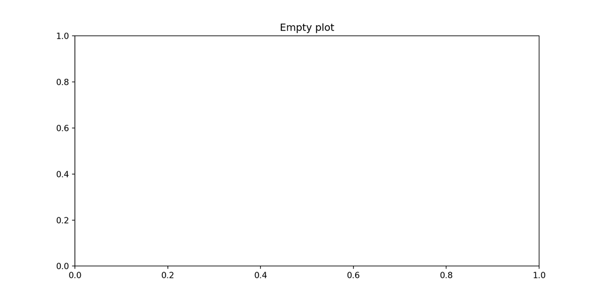

```python
fig, axes = plt.subplots()

axes.set_title("Empty plot")

plt.show()
```

## Basic Plot types (1 variable)

### Histogram

Histograms show the distribution of a single continuous variable.

Split data into “bins” and then count observations in each bin:

### Histogram

Example:

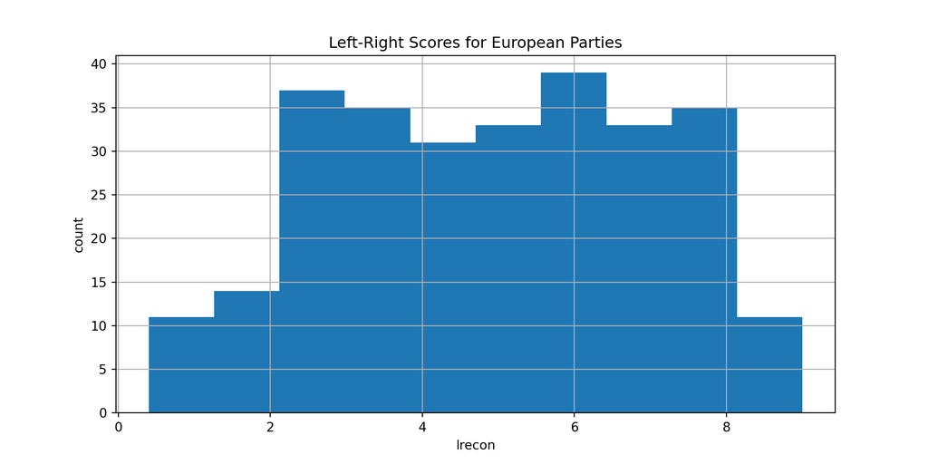

```python
fig, axes = plt.subplots()
ches['lrecon'].hist(ax=axes)
axes.set_title("Left-Right Scores for European Parties")
axes.set_xlabel("lrecon")
axes.set_ylabel('count')
plt.show()
```

### Histogram

Usually, the default setting works here, but you can adjust the number of bins up or down to change the sizing:

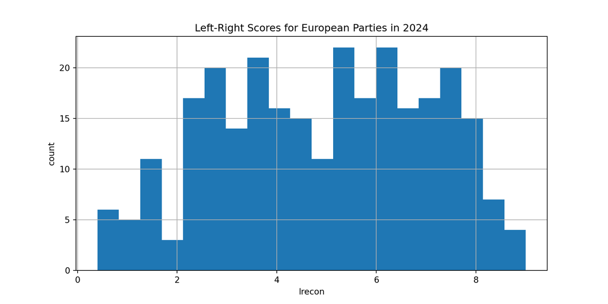

```python
fig, axes = plt.subplots()
ches['lrecon'].hist(bins=20, ax=axes)
axes.set_title("Left-Right Scores for European Parties in 2024")
axes.set_xlabel("lrecon")
axes.set_ylabel('count')
plt.show()
```

### Histogram

We can also set `grid=False` to remove the grid lines and adjust the size (along with several other options documented [here](https://matplotlib.org/stable/api/_as_gen/matplotlib.pyplot.hist.html))

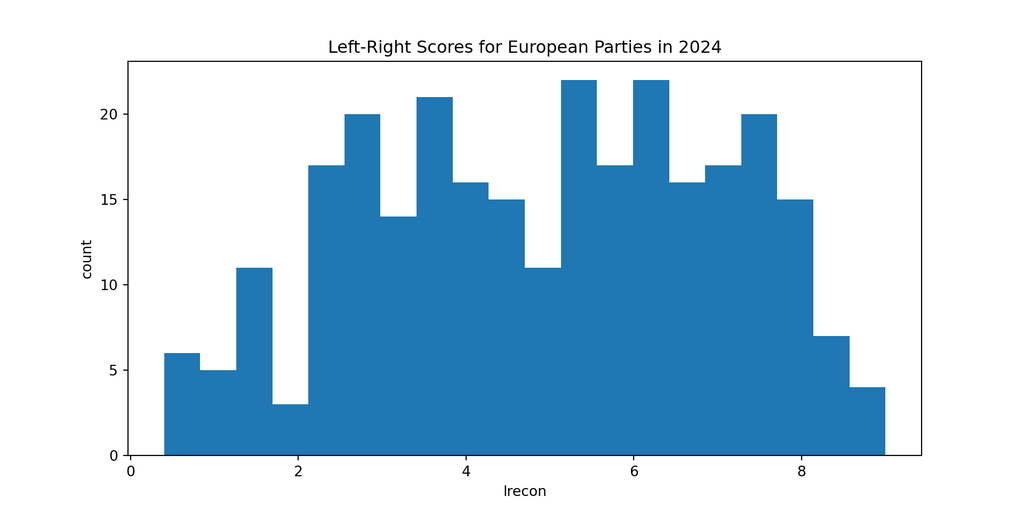

```python
fig, axes = plt.subplots( figsize = (10, 5))

ches['lrecon'].hist(bins = 20, grid=False, ax=axes)
axes.set_title("Left-Right Scores for European Parties in 2024")
axes.set_xlabel("lrecon")
axes.set_ylabel('count')
plt.show()
```

### Density plot

Kernel density plots are like a “smooth” version of a histogram.

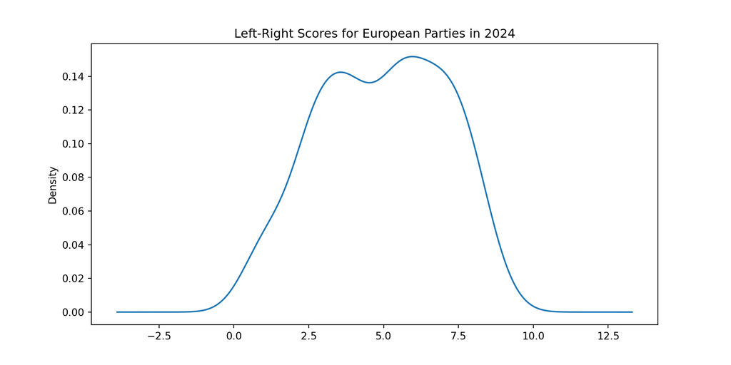

```python
fig, axes = plt.subplots()
ches['lrecon'].plot.density(ax=axes)
axes.set_title("Left-Right Scores for European Parties in 2024")
plt.show()
```

### Density plot

- One disadvantage relative to a histogram is that the Y-axis is not readily interpretable

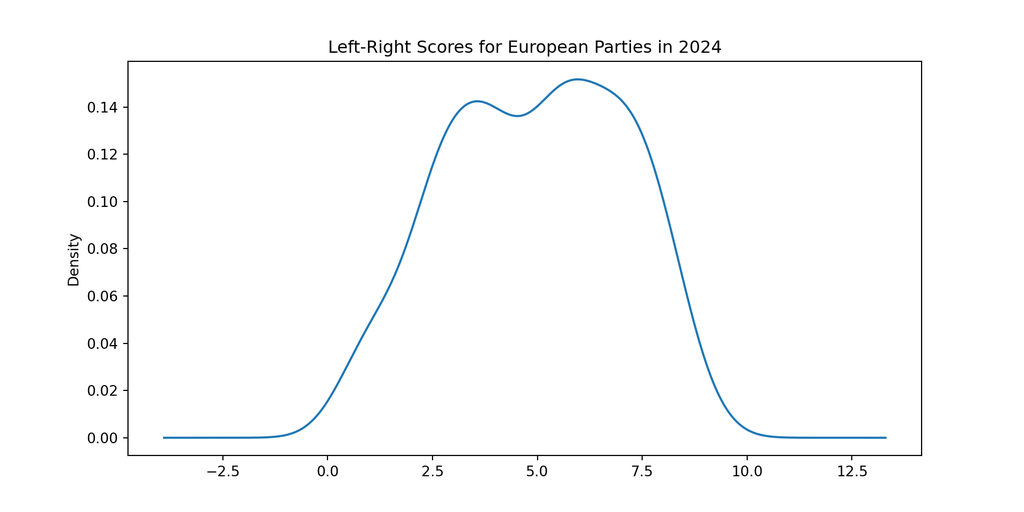

```python
fig, axes = plt.subplots()

ches['lrecon'].plot.density(ax=axes)
axes.set_title("Left-Right Scores for European Parties in 2024")
plt.show()
```

### Density plot

- One disadvantage relative to a histogram is that the Y-axis is not readily interpretable
- One advantage is that it can be easier to show multiple density plots together

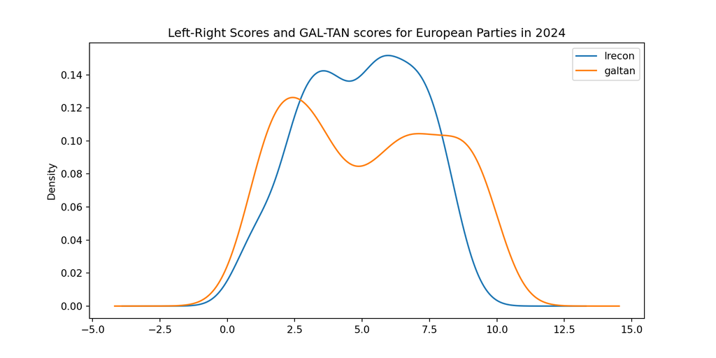

```python
fig, axes = plt.subplots()


ches[['lrecon', 'galtan']].plot.density(ax=axes)
axes.set_title("Left-Right Scores and GAL-TAN scores for European Parties in 2024")
plt.show()
```

### Bar plot

One variable bar plots will give the count of each unique value in a column.

Most often, we’ll be using the output from an aggregation function like `value_counts` first, then plotting the resulting frequency table.

### Bar plot example

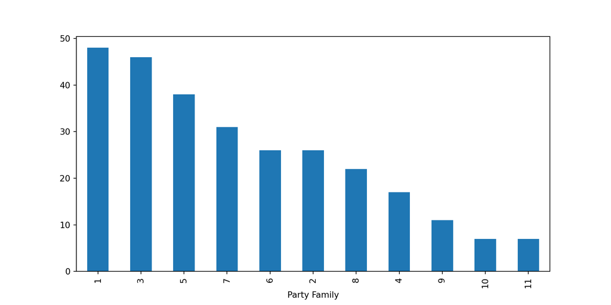

```python
fig, axes = plt.subplots()
ches.family.value_counts().plot.bar(ax=axes)
axes.set_xlabel("Party Family")
plt.show()
```

### Bar plot

`barh` will generate a horizontal barplot

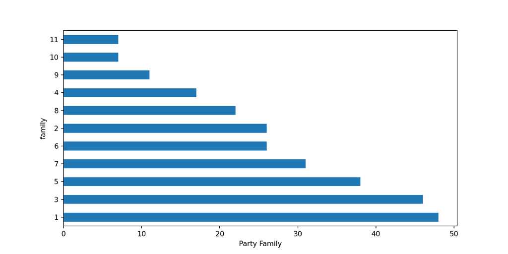

```python
fig, axes = plt.subplots()
ches.family.value_counts().plot.barh(ax=axes)
axes.set_xlabel("Party Family")
plt.show()
```

### Bar plot

And we can do things like adjust the color

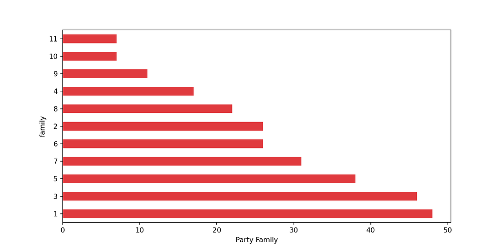

```python
fig, axes = plt.subplots()
ches.family.value_counts().plot.barh(color='#E03A3E', ax=axes)
axes.set_xlabel("Party Family")
plt.show()
```

### Pie charts

Finally, pie charts *can be* useful for giving the proportion of results belonging to each group (but in many cases a bar chart may convey this information more clearly)

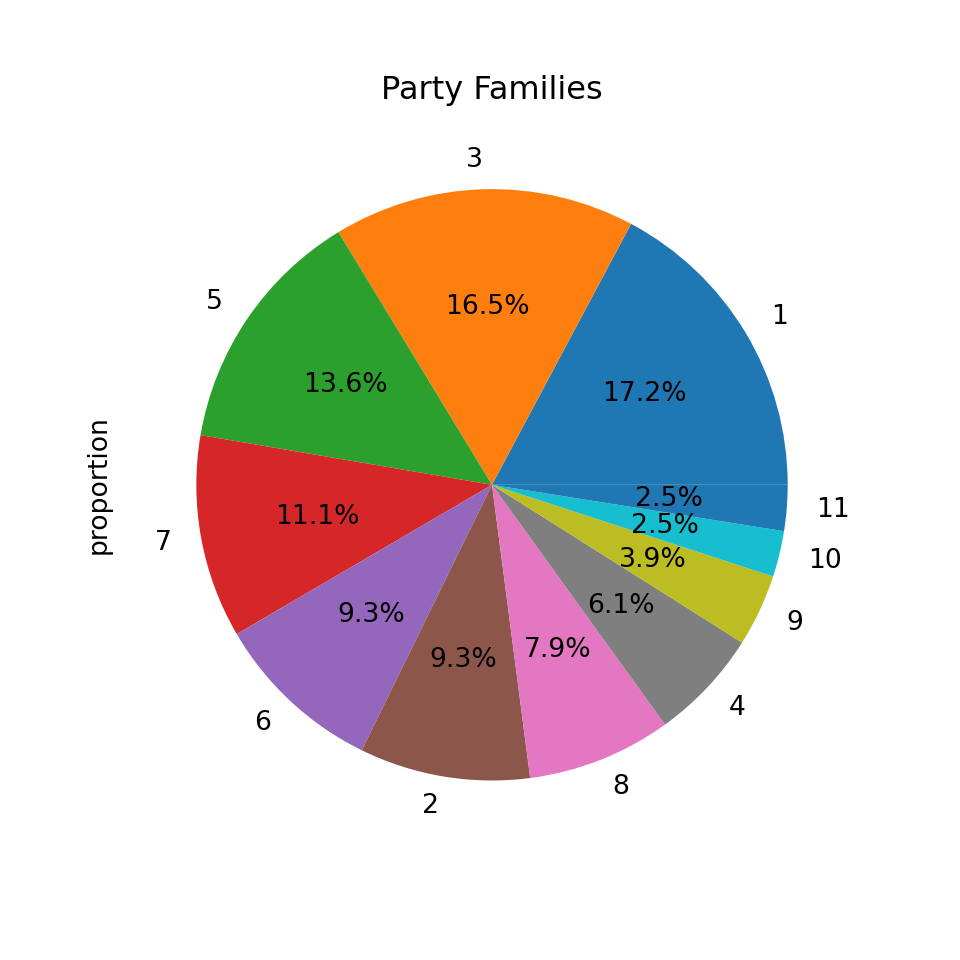

```python
fig, axes = plt.subplots(figsize=(5,5))
ches.family.value_counts(normalize='index').plot.pie(autopct='%.1f%%', ax=axes)
axes.set_title('Party Families')
plt.show()
```

## Basic Plot types (2 or more variables)

### Boxplots

Boxplots will give a five number summary (minimum, maximum, 25th, 50th, and 75th percentiles) of a continuous variable.

They can work to describe a single variable, but they’re most useful for examining the relationship between a category and a numeric variable.

### Boxplots Example

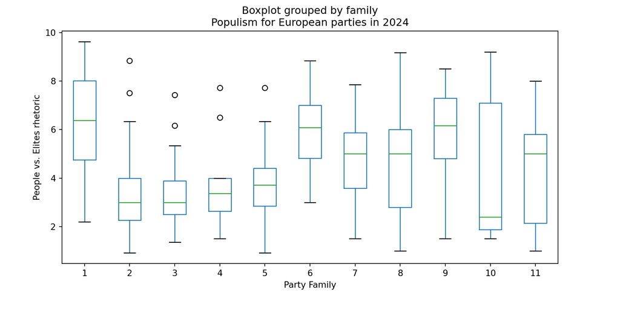

```python
fig, axes = plt.subplots()
ches.boxplot(by='family', column='people_v_elite', figsize=(10,5), grid=False, ax=axes)
axes.set_xlabel("Party Family")
axes.set_ylabel("People vs. Elites rhetoric")
axes.set_title("Populism for European parties in 2024")
plt.show()
```

### Bar charts (2-way)

2-way bar charts will work best for visualizing a 2-way crosstab, or showing the average across values of a categorical variable.

### Bar charts (2-way) Example

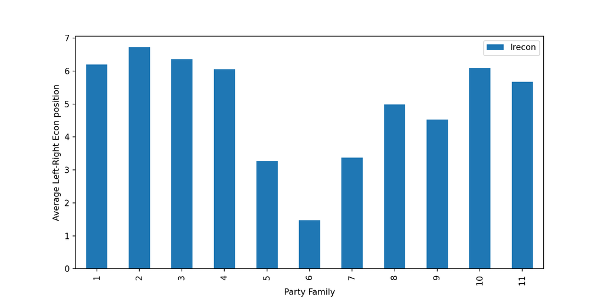

```python
fig, axes = plt.subplots()
ches.pivot_table(index='family', values='lrecon').plot.bar(ax=axes)
axes.set_xlabel("Party Family")
axes.set_ylabel("Average Left-Right Econ position")
```

### Scatter plots

Scatter plots will work best when both variables are continuous.

Be careful about overplotting: if there are only a small number of response categories, a scatter plot may give you weird looking results because multiple points end up right on top of each other.

### Scatter plot example

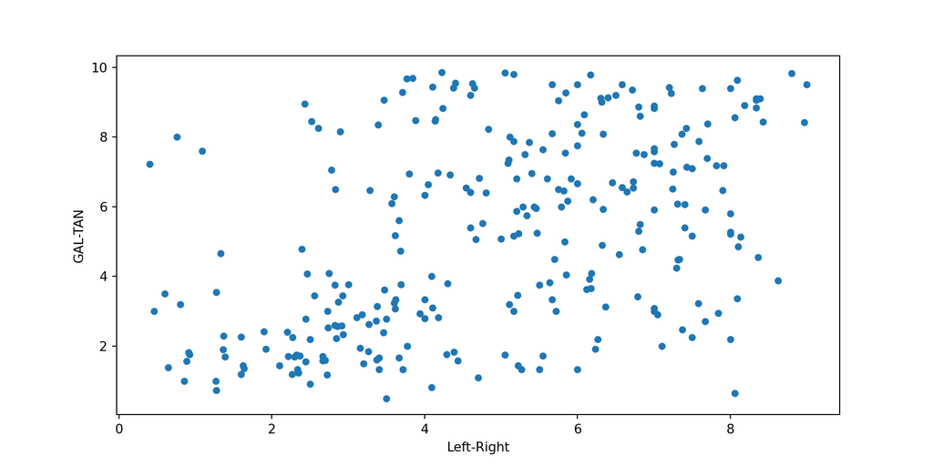

```python
fig, axes = plt.subplots()
ches.plot.scatter(x='lrecon', y='galtan', ax=axes)
axes.set_xlabel("Left-Right")
axes.set_ylabel("GAL-TAN")
plt.show()
```

### Multiple plots

Matplot makes it relatively easy to combine multiple plots into the same figure. You’ll just need to specify the number of rows and columns for your figure, and then assign a plot to each axis using an index.

### Multiple plots example

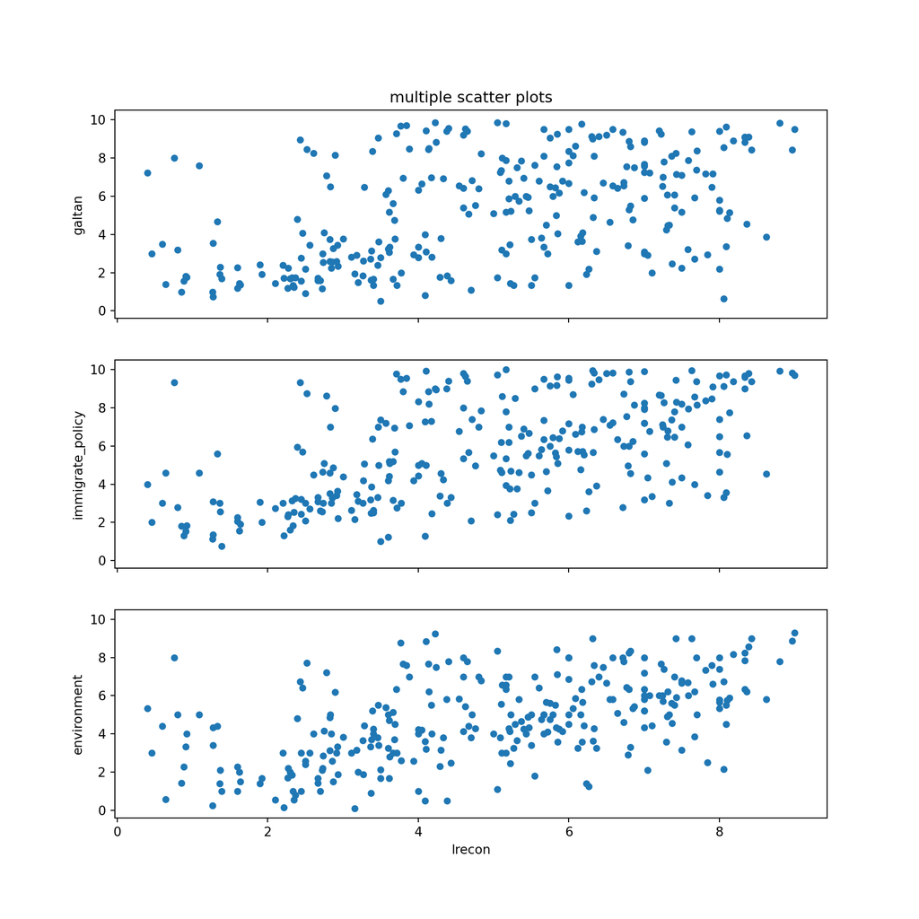

```python
fig, axes = plt.subplots(3, 1, sharex=True, sharey=True, figsize=(10,10))
ches.plot.scatter(x='lrecon', y='galtan', ax=axes[0])
ches.plot.scatter(x='lrecon', y='immigrate_policy', ax=axes[1])
ches.plot.scatter(x='lrecon', y='environment', ax=axes[2])

axes[0].set_title("multiple scatter plots")

plt.show()
```